# What value does ECDC's RespiCast have — and could it have?

Evidence from the survey of national focal points · a supplement to the summary

Independent analysis · de-identified ECDC RespiCompass-2024 NFP survey · n = 19 countries

In 2024, ECDC surveyed the **National Focal Points (NFPs)** for respiratory viruses — the designated national contacts at each country's public-health institute. **Nineteen countries replied**, one collective answer each. The survey asked how much modelling each institute can do itself, how **aware** they are of ECDC's modelling products, which national decisions those products might inform, and which outputs they would prefer. This supplement gathers the answers that bear on one question: what value does ECDC's weekly short-term forecasting service, **RespiCast**, have today — and what value could it have? Every figure is generated directly from the survey.

**In one line.** RespiCast is the ECDC forecast that national institutes most want, and for most countries it is the **only** forecast they have — yet its realised value is still modest and held back on the **demand side** (awareness, interpretability, and a route into decisions), not by any shortage of forecasts.

## 1The need — most countries cannot forecast for themselves

For most member states, an external forecast is the **only** forecast. **13 of the 19 institutes (68%)** have no in-house mathematical modeller at all, and only one has a team larger than five. So for two-thirds of responding countries RespiCast is not a second opinion — it is their forecasting capability. This is the single biggest reason the service has value at all.

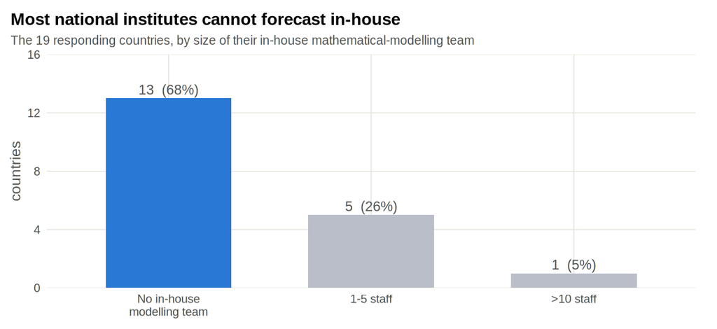

Survey question on in-house modelling staff · 19 countries

## 2The preference — forecasts are wanted more than scenarios

Asked which ECDC product will be most useful, countries clearly favour forecasts over scenarios. **Ten of 19 (53%)** expect both to be useful; among those who picked just one, **RespiCast (forecasts) was chosen five times to RespiCompass's (scenarios) one** — a 5:1 margin. Only 3 (16%) expected neither to help. In the open comments, NFPs explain why: short-term forecasts are seen as **more reliable and more actionable** than long-horizon (e.g. six-month) scenarios.

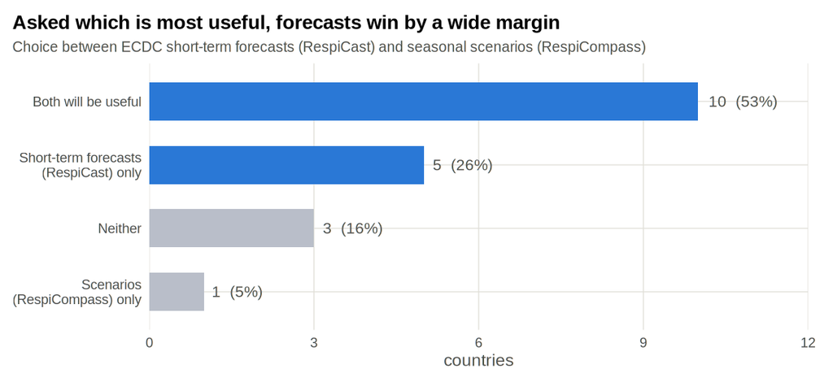

Survey question on the most valuable output · 19 countries

## 3Current standing — still not widely known

The survey asked how **aware** each institute is of ECDC's modelling outputs (0 = not aware, 5 = fully aware) — this measures awareness, not use. Awareness of RespiCast averages **2.1** — below the older COVID-era products (2.7–3.9) and above only RespiCompass (1.4). This is largely a **recency** effect: awareness tracks how long an output has been in circulation, so the newest products are the least known, and about **one in six (17%)** NFPs were not yet aware of RespiCast at all. It is an awareness gap, not a verdict on value.

Tellingly, awareness is **no higher where a country has no team of its own** (about 2.1 either way), and **every institute entirely unaware** of RespiCast is one with no in-house team — so the awareness gap sits exactly where the need is greatest, and is cheap to close. Whether closing it converts into **use** the survey does not measure; the open comments are the only signal there.

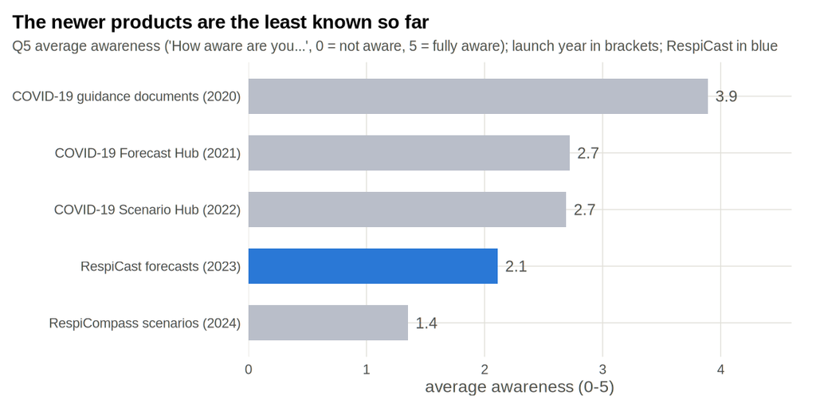

Survey question on awareness of each ECDC modelling output ("How aware are you...", 0–5)

## 4Where the value lands — awareness today, resources not yet

Where would forecasts actually feed decisions? Most often in **situational awareness**: 58% say ECDC modelling is likely to inform surveillance activities. Vaccination-campaign planning follows at 37%. The classic forecasting use case — **planning hospital and healthcare capacity** — is the **least** likely, at just 16%. Today's value is concentrated in knowing where a season stands, not yet in committing scarce resources — which points to where the next gains could come from.

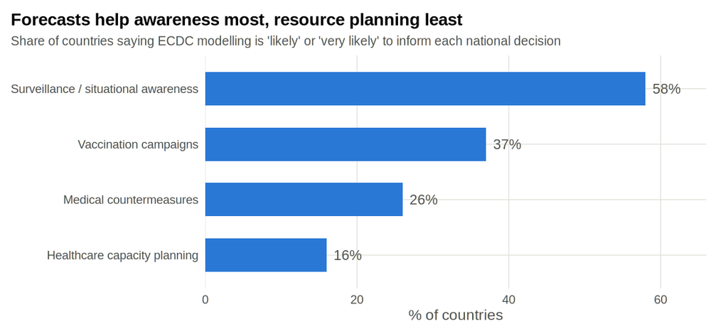

Survey question on decisions ECDC modelling would inform · % 'likely / very likely'

## 5The ceiling — a missing pathway into decisions

The main brake on value is not the forecast but the **pathway to use it**. Only **9 of 19 institutes (48%)** agree there is a clear, consistent mechanism to fold modelling into national public-health decisions; **6 (32%)** disagree. Even an accurate, timely forecast stalls if there is no route from the chart to the decision — so building that route is among the highest-leverage things ECDC and member states could do.

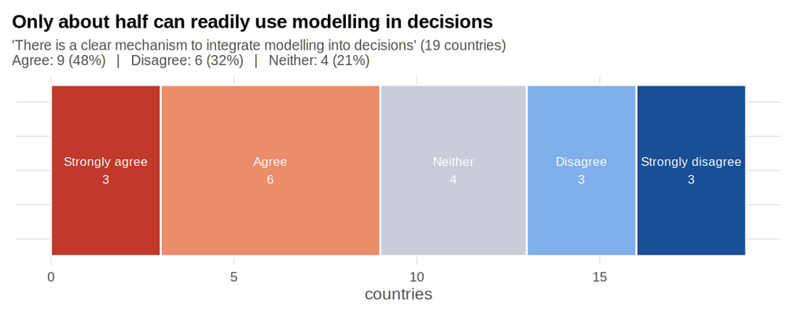

Survey question on a clear mechanism to integrate modelling into decisions · 19 countries

## 6Value it has, and value it could have

| Value RespiCast has today | Latent value it could have |
| --- | --- |
| The most-wanted ECDC forecast (chosen 5:1 over scenarios) | Reach the 68% of countries with no team of their own, who are currently no more aware than the rest |
| The **only** forecast most countries have | Become usable by the non-modellers who consume it — via plain-language outputs and short training |
| Trusted more than long-horizon scenarios | Earn decision-grade trust with a transparent skill / track-record (accuracy shown, not assumed) |
| Feeds situational awareness (surveillance, 58%) | Extend into higher-stakes planning — healthcare capacity is only 16% today |
| Delivered reliably (an ensemble almost every week) | Be wired into the decision — only 48% report a clear mechanism to use it, and into surveillance data (ERVISS) |

The open comments point to the same levers, and add one more: a recurring ask for **ECDC to back, and help fund, national modelling capacity** — so that countries can absorb and act on forecasts in the first place.

## 7How to read these numbers

Nineteen countries replied (of ~30 EU/EEA NFPs), so every share moves by about five points per country — read the figures as **direction and magnitude, not precise percentages**. The 0–5 scale measures **awareness** ("how aware are you…"), not use or a usefulness rating. "Which will be most useful" is a stated **expectation** — several respondents note they have not yet used the products. Newer products have had less time in circulation, which depresses their awareness scores. None of this measures forecast **accuracy**; it measures what national institutes say they need, value and use.